# 732A91 Lab 2

Fanny Karelius (fanka300), Milda Poceviciute (milpo192)

15 May 2018

# Question 1: Poisson regression - the MCMC way

The $y_i$th ($i=1,...,n$) count of for the $i$th observation in the sample follows the following regression model:
$$y_i|\beta \sim Poisson[exp(x_i^{T}\beta)]$$
where $x_i$ is a $p$-dimensional vector of covariates.

The data set contains observations form 1000 eBay auctions of coins. The response variable is nBids (the number of bids in each auction). The covariates are Const (intercept), PowerSeller, VerifyID, Sealed, MinBlem, MajBlem, LargNeg, LogBook and MinBidShare.

## a)

```r
data <- read.table("eBayNumberOfBidderdata.dat", header = TRUE)
c <- c(1,3:ncol(data))
data_noC <- data[,c]
glm_fit <- glm(nBids~., family=poisson, data_noC)
summary(glm_fit)
```

```
##
## Call:
## glm(formula = nBids ~ ., family = poisson, data = data_noC)
##
## Deviance Residuals:
##     Min       1Q   Median       3Q      Max
## -3.5800  -0.7222  -0.0441   0.5269   2.4605
##
## Coefficients:
##             Estimate Std. Error z value Pr(>|z|)
## (Intercept)  1.07244    0.03077  34.848  < 2e-16 ***
## PowerSeller -0.02054    0.03678  -0.558   0.5765
## VerifyID    -0.39452    0.09243  -4.268 1.97e-05 ***
## Sealed       0.44384    0.05056   8.778  < 2e-16 ***
## Minblem     -0.05220    0.06020  -0.867   0.3859
## MajBlem     -0.22087    0.09144  -2.416   0.0157 *
## LargNeg      0.07067    0.05633   1.255   0.2096
## LogBook     -0.12068    0.02896  -4.166 3.09e-05 ***
## MinBidShare -1.89410    0.07124 -26.588  < 2e-16 ***
## ---
## Signif. codes:  0 '***' 0.001 '**' 0.01 '*' 0.05 '.' 0.1 ' ' 1
##
## (Dispersion parameter for poisson family taken to be 1)
##
##     Null deviance: 2151.28  on 999  degrees of freedom
## Residual deviance:  867.47  on 991  degrees of freedom
## AIC: 3610.3
##
## Number of Fisher Scoring iterations: 5
```

From the summary we see that the Intercept, VerifyID, Sealed, MajBlem, LogBook and MinBidShare are significant covariates.

## b)

Here we do Bayesian analysis of the Poisson regression. The prior is $\beta\sim N(0,100\cdot(X^TX)^{-1})$, where $X$ is a $n\times p$ covariate matrix, which is called Zellner’s g-prior. We assume that the posterior density is approximately multivariate normal:
$$\beta|y\sim N(\tilde{\beta}, J_y^{-1}(\tilde{\beta}))$$
where $\tilde{\beta}$ is the posterior mode and $J_y(\tilde{\beta})$ is the negative Hessian at the posterior mode.

```r
library(mvtnorm)

log_poisson <- function(beta, y, x){
  x <- as.matrix(x)
  xtx <- solve(t(x)%*%x)
  y <- as.matrix(y)
  lin_pred <- x%*%beta
  loglik <- sum(y*lin_pred-exp(lin_pred))/sum(log(factorial(y)))
  logprior <- dmvnorm(beta, mean=as.vector(rep(0,ncol(x))), sigma=100*xtx, log = TRUE)
  logpost <- loglik+logprior
  logpost
}

betas_init <- as.vector(rep(0,ncol(data)-1))
y <- data$nBids
x<- data[,2:ncol(data)]
optim_fit <- optim(betas_init, log_poisson, gr=NULL, y, x, method=c("BFGS"),control=list(fnscale=-1), hessian=TRUE)

beta_tilde <- optim_fit$par
hessian <- -1*optim_fit$hessian
inv_hessian <- solve(hessian)

post_approx <- rmvnorm(n=1000, mean=beta_tilde, sigma=inv_hessian)
colnames(post_approx) <- colnames(x)
phi_b <- exp(post_approx)
```

```
## [1] "The posterior mode:"
```

```
## [1]  0.072645168 -0.002363413 -0.016290961  0.041358118 -0.009751628
## [6] -0.029472899  0.008762620 -0.002913510 -0.142679215
```

```
## [1] "The negative inverse Hessian:"
```

```
##               [,1]        [,2]        [,3]        [,4]        [,5]
##  [1,]  0.277961151 -0.24888154 -0.07709695 -0.09948810 -0.15502241
##  [2,] -0.248881540  0.47523863 -0.09261390 -0.06771881  0.04657194
##  [3,] -0.077096951 -0.09261390  1.90532349 -0.07224421  0.01640144
##  [4,] -0.099488096 -0.06771881 -0.07224421  1.15668610  0.12051833
##  [5,] -0.155022408  0.04657194  0.01640144  0.12051833  1.17985533
##  [6,] -0.131675787 -0.03682095  0.10972495  0.15358135  0.13032112
##  [7,] -0.171931301  0.05579491  0.13735299  0.12713033  0.03627697
##  [8,] -0.008658968  0.05067481 -0.20219725 -0.01758610  0.03546605
##  [9,]  0.097638506 -0.17871020 -0.29922724  0.07954534  0.03369626
##              [,6]         [,7]         [,8]         [,9]
##  [1,] -0.13167579 -0.171931301 -0.008658968  0.097638506
##  [2,] -0.03682095  0.055794911  0.050674812 -0.178710201
##  [3,]  0.10972495  0.137352992 -0.202197252 -0.299227238
##  [4,]  0.15358135  0.127130334 -0.017586105  0.079545339
##  [5,]  0.13032112  0.036276967  0.035466048  0.033696256
##  [6,]  2.88186700  0.161995542 -0.031398337  0.145251562
##  [7,]  0.16199554  1.305247679 -0.075269365  0.002281561
##  [8,] -0.03139834 -0.075269365  0.275074867  0.242765592
##  [9,]  0.14525156  0.002281561  0.242765592  1.034958424
```

## c)

The Metropolis algorithm simulates from the actual posterior of $\beta$. We use
$$\theta_p|\theta_c\sim N(\theta_c,\tilde{c}\cdot\Sigma)$$
where $\Sigma=J_y^{-1}(\tilde{\beta})$, to draw $\theta$s. The value $\tilde{c}$ is a tuning parameter. The acceptance rate is given by
$$\alpha=\min\{1,\frac{p(\theta_p|y)}{p(\theta_c|y)}=\exp[\log(p(\theta_p|y))-log(p(\theta_c|y))]\}$$
. We aim to have an acceptance rate of the Metropolis algorithm around 30%.

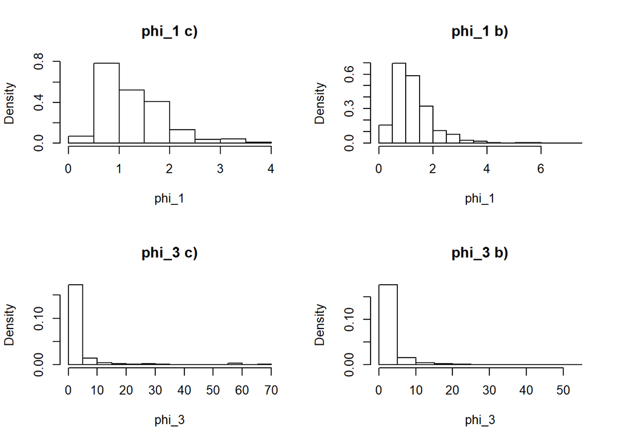

```r
metropolis <- function(n, c, sigma, logpostfun, theta,...){
  thetas <- matrix(nrow=n+1, ncol=length(theta))
  thetas[1,]<-theta
  temp1 <-logpostfun(thetas[1,],...)
  acc_prob <- vector(length=n)
  acc_prob[1] <- 0
  for(i in 1:n){
    temp_theta<-rmvnorm(n=1, thetas[i,], c*sigma)
    temp2 <-logpostfun(as.vector(temp_theta),...)
    acc_prob[i+1] <- min(1,exp(temp2-temp1))
    u <- runif(n = 1,0,1)
    if(u>acc_prob[i+1]){
      thetas[i+1,]<-thetas[i,]
    }
    else{
      thetas[i+1,] <- temp_theta
      temp1 <- temp2
    }
  }
  data.frame(thetas, "acc.prob"=acc_prob)
}
metro2 <- metropolis(1000, c=1, sigma=inv_hessian, log_poisson, theta=betas_init, y=y, x=x)
metro <- metropolis(1000, c=0.5, sigma=inv_hessian, log_poisson, theta=betas_init, y=y, x=x)

acc_prob <- as.vector(metro$acc.prob)
avg_acc <- mean(acc_prob)

beta_metro <- as.matrix(metro[,1:length(betas_init)])
phi <- exp(beta_metro)

par(mfrow=c(2,2))
hist(phi[,1], freq = FALSE, main="phi_1 c)", xlab = "phi_1")
hist(phi_b[,1], freq = FALSE, main="phi_1 b)", xlab = "phi_1")
hist(phi[,3], freq = FALSE, main="phi_3 c)", xlab = "phi_3")
hist(phi_b[,3], freq = FALSE, main="phi_3 b)", xlab = "phi_3")
```

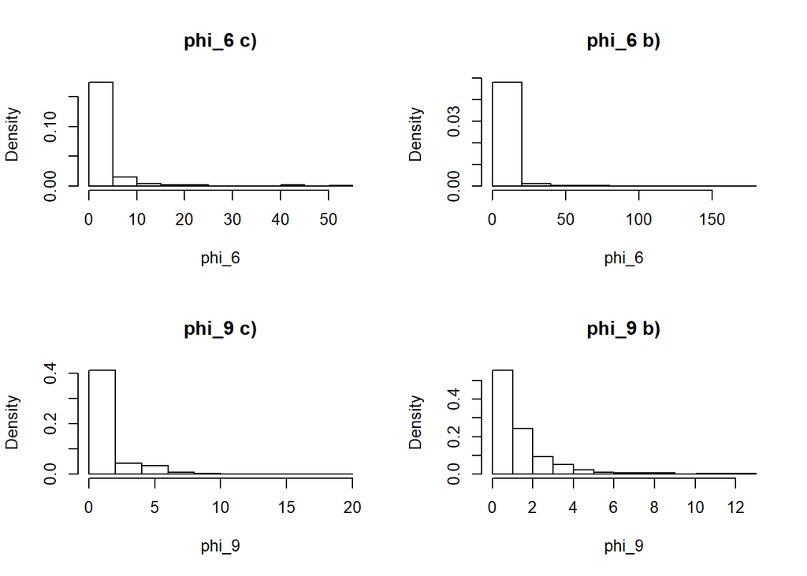

```r
par(mfrow=c(2,2))
hist(phi[,6], freq = FALSE, main="phi_6 c)", xlab = "phi_6")
hist(phi_b[,6], freq = FALSE, main="phi_6 b)", xlab = "phi_6")
hist(phi[,9], freq = FALSE, main="phi_9 c)", xlab = "phi_9")
hist(phi_b[,9], freq = FALSE, main="phi_9 b)", xlab = "phi_9")
```

## d)

We simulate from the predictive distribution of the number of bidders (nBids) using the MCMC draws from c).

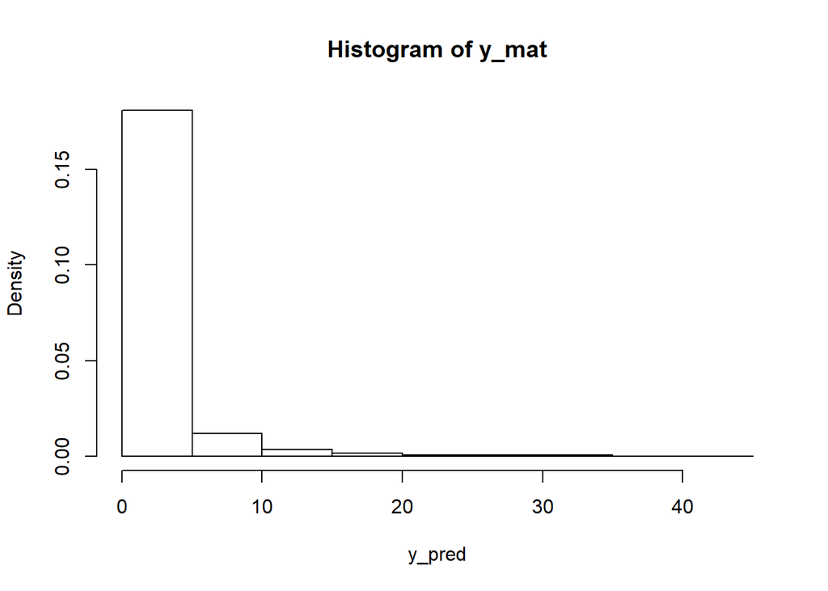

```r
x_vec <- c(1,1,1,1,0,0,0,1,0.5)
lambda <- exp(x_vec%*%t(beta_metro))
y_mat <- apply(lambda, 1, function(i){rpois(1000, i)})
hist(y_mat, freq = FALSE, xlab="y_pred")
```

```r
prob_y0 <- length(y_mat[y_mat==0])/length(y_mat)
```

```
## Probability of nBids=0:  0.411
```

# Appendix

```r
data <- read.table("eBayNumberOfBidderdata.dat", header = TRUE)
c <- c(1,3:ncol(data))
data_noC <- data[,c]
glm_fit <- glm(nBids~., family=poisson, data_noC)
summary(glm_fit)
library(mvtnorm)

log_poisson <- function(beta, y, x){
  x <- as.matrix(x)
  xtx <- solve(t(x)%*%x)
  y <- as.matrix(y)
  lin_pred <- x%*%beta
  loglik <- sum(y*lin_pred-exp(lin_pred))/sum(log(factorial(y)))
  logprior <- dmvnorm(beta, mean=as.vector(rep(0,ncol(x))), sigma=100*xtx, log = TRUE)
  logpost <- loglik+logprior
  logpost
}

betas_init <- as.vector(rep(0,ncol(data)-1))
y <- data$nBids
x<- data[,2:ncol(data)]
optim_fit <- optim(betas_init, log_poisson, gr=NULL, y, x, method=c("BFGS"),control=list(fnscale=-1), hessian=TRUE)

beta_tilde <- optim_fit$par
hessian <- -1*optim_fit$hessian
inv_hessian <- solve(hessian)

post_approx <- rmvnorm(n=1000, mean=beta_tilde, sigma=inv_hessian)
colnames(post_approx) <- colnames(x)
phi_b <- exp(post_approx)
print("The posterior mode:")
beta_tilde
print("The negative inverse Hessian:")
inv_hessian
metropolis <- function(n, c, sigma, logpostfun, theta,...){
  thetas <- matrix(nrow=n+1, ncol=length(theta))
  thetas[1,]<-theta
  temp1 <-logpostfun(thetas[1,],...)
  acc_prob <- vector(length=n)
  acc_prob[1] <- 0
  for(i in 1:n){
    temp_theta<-rmvnorm(n=1, thetas[i,], c*sigma)
    temp2 <-logpostfun(as.vector(temp_theta),...)
    acc_prob[i+1] <- min(1,exp(temp2-temp1))
    u <- runif(n = 1,0,1)
    if(u>acc_prob[i+1]){
      thetas[i+1,]<-thetas[i,]
    }
    else{
      thetas[i+1,] <- temp_theta
      temp1 <- temp2
    }
  }
  data.frame(thetas, "acc.prob"=acc_prob)
}
metro2 <- metropolis(1000, c=1, sigma=inv_hessian, log_poisson, theta=betas_init, y=y, x=x)
metro <- metropolis(1000, c=0.5, sigma=inv_hessian, log_poisson, theta=betas_init, y=y, x=x)

acc_prob <- as.vector(metro$acc.prob)
avg_acc <- mean(acc_prob)

beta_metro <- as.matrix(metro[,1:length(betas_init)])
phi <- exp(beta_metro)

par(mfrow=c(2,2))
hist(phi[,1], freq = FALSE, main="phi_1 c)", xlab = "phi_1")
hist(phi_b[,1], freq = FALSE, main="phi_1 b)", xlab = "phi_1")
hist(phi[,3], freq = FALSE, main="phi_3 c)", xlab = "phi_3")
hist(phi_b[,3], freq = FALSE, main="phi_3 b)", xlab = "phi_3")
par(mfrow=c(2,2))
hist(phi[,6], freq = FALSE, main="phi_6 c)", xlab = "phi_6")
hist(phi_b[,6], freq = FALSE, main="phi_6 b)", xlab = "phi_6")
hist(phi[,9], freq = FALSE, main="phi_9 c)", xlab = "phi_9")
hist(phi_b[,9], freq = FALSE, main="phi_9 b)", xlab = "phi_9")
x_vec <- c(1,1,1,1,0,0,0,1,0.5)
lambda <- exp(x_vec%*%t(beta_metro))
y_mat <- apply(lambda, 1, function(i){rpois(1000, i)})
hist(y_mat, freq = FALSE, xlab="y_pred")
prob_y0 <- length(y_mat[y_mat==0])/length(y_mat)
cat("Probability of nBids=0: ", prob_y0)
```